# Vignette Title

## 11.5

We first give the answer of 11.4.

- 11.4

```r
k <- c(4:25,100,500,1000) #values of ks
s <- numeric(25) # to store the values of roots
for (i in 1:25) {
g <- function(a)
{
  q1 <- sqrt(a^2*(k[i]-1)/(k[i]-(a^2)))
  p1 <- pt(q1, k[i]-1,lower.tail = F, log.p = TRUE)
  q2 <- sqrt(a^2*k[i]/(k[i]+1-(a^2)))
  p2 <- pt(q2, k[i],lower.tail = F, log.p = TRUE)
  return(p1-p2)
}
s[i] <- uniroot(g,c(-1,sqrt(k[i])-0.01))$root
}
r <- cbind(k,s)
r
```

```
##          k        s
##  [1,]    4 1.492103
##  [2,]    5 1.533559
##  [3,]    6 1.562745
##  [4,]    7 1.584429
##  [5,]    8 1.601158
##  [6,]    9 1.614525
##  [7,]   10 1.625413
##  [8,]   11 1.634378
##  [9,]   12 1.642026
## [10,]   13 1.648546
## [11,]   14 1.654196
## [12,]   15 1.659103
## [13,]   16 1.663449
## [14,]   17 1.667304
## [15,]   18 1.670700
## [16,]   19 1.673802
## [17,]   20 1.676614
## [18,]   21 1.679149
## [19,]   22 1.681471
## [20,]   23 1.683595
## [21,]   24 1.685546
## [22,]   25 1.687352
## [23,]  100 1.720608
## [24,]  500 1.729745
## [25,] 1000 1.730898
```

- 11.5

For the computer can caculate the equation, we do some transformation of the equation, we change the integrating range to $(c_k,\infty)$, and take the logarithm of both sides.

```r
k <- c(4:25,100,500,1000)
s <- numeric(25)
for (i in 1:25) {
  f <- function(u, k) (1+u^2/(k-1))^(-k/2)
  ck <- function(a, k) sqrt(a^2*(k-1)/(k-a^2))
  g <- function(a){
    in1 <- integrate(f, lower = ck(a, k[i]), upper = Inf, k = k[i])$value
    in2 <- integrate(f, lower = ck(a, k[i]+1), upper = Inf, k = k[i]+1)$value
    p1 <- log(2) + lgamma(k[i]/2) - 0.5*log(pi*(k[i]-1)) - lgamma((k[i]-1)/2) + log(in1)
    p2 <- log(2) + lgamma((k[i]+1)/2) - 0.5*log(pi*k[i]) - lgamma(k[i]/2) + log(in2)
    return(p1-p2)
  }
  s[i] <- uniroot(g,c(-1, 1.9))$root
}
r <- cbind(k,s)
r
```

```
##          k        s
##  [1,]    4 1.492132
##  [2,]    5 1.533558
##  [3,]    6 1.562760
##  [4,]    7 1.584433
##  [5,]    8 1.601207
##  [6,]    9 1.614526
##  [7,]   10 1.625386
##  [8,]   11 1.634410
##  [9,]   12 1.642026
## [10,]   13 1.648540
## [11,]   14 1.654174
## [12,]   15 1.659096
## [13,]   16 1.663433
## [14,]   17 1.667283
## [15,]   18 1.670724
## [16,]   19 1.673817
## [17,]   20 1.676614
## [18,]   21 1.679154
## [19,]   22 1.681472
## [20,]   23 1.683595
## [21,]   24 1.685546
## [22,]   25 1.687347
## [23,]  100 1.720582
## [24,]  500 1.729739
## [25,] 1000 1.730892
```

As we show, the solutions and the points $A(k)$ in Exercise 11.4 are almost the same.

A-B-O

```r
library(nloptr)
# Mle
eval_f0 = function(x,x1,n.A=28,n.B=24,nOO=41,nAB=70) {

  r1 = 1-sum(x1)
  nAA = n.A*x1[1]^2/(x1[1]^2+2*x1[1]*r1)
  nBB = n.B*x1[2]^2/(x1[2]^2+2*x1[2]*r1)
  r = 1-sum(x)
  return(-2*nAA*log(x[1])-2*nBB*log(x[2])-2*nOO*log(r)-
           (n.A-nAA)*log(2*x[1]*r)-(n.B-nBB)*log(2*x[2]*r)-nAB*log(2*x[1]*x[2]))
}


# constraint
eval_g0 = function(x,x1,n.A=28,n.B=24,nOO=41,nAB=70) {
  return(sum(x)-0.999999)
}

opts = list("algorithm"="NLOPT_LN_COBYLA",
             "xtol_rel"=1.0e-8)
mle = NULL
r = matrix(0,1,2)
r = rbind(r,c(0.2,0.35))# the beginning value of p0 and q0
j = 2
while (sum(abs(r[j,]-r[j-1,]))>1e-8) {
res = nloptr( x0=c(0.3,0.25),
               eval_f=eval_f0,
               lb = c(0,0), ub = c(1,1),
               eval_g_ineq = eval_g0,
               opts = opts, x1=r[j,],n.A=28,n.B=24,nOO=41,nAB=70 )
j = j+1
r = rbind(r,res$solution)
mle = c(mle,eval_f0(x=r[j,],x1=r[j-1,]))
}
#the result of EM algorithm
r
```

```
##            [,1]      [,2]
##  [1,] 0.0000000 0.0000000
##  [2,] 0.2000000 0.3500000
##  [3,] 0.3162298 0.3089571
##  [4,] 0.3260961 0.3098301
##  [5,] 0.3271807 0.3103186
##  [6,] 0.3273212 0.3104097
##  [7,] 0.3273409 0.3104241
##  [8,] 0.3273438 0.3104263
##  [9,] 0.3273442 0.3104266
## [10,] 0.3273442 0.3104267
## [11,] 0.3273442 0.3104267
## [12,] 0.3273442 0.3104267
```

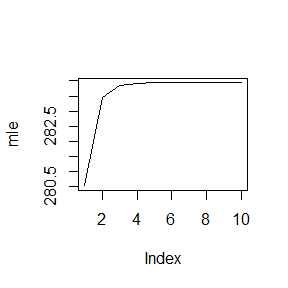

```r
#the max likelihood values
plot(mle,type = 'l')
```

Homework 10

204.3

```r
formulas <- list(
  mpg ~ disp,
  mpg ~ I(1 / disp),
  mpg ~ disp + wt,
  mpg ~ I(1 / disp) + wt
)

la1 <- lapply(formulas, lm, data = mtcars) #lapply

lo1 <- vector("list", length(formulas)) #for loop
for (i in seq_along(formulas)) {
  lo1[[i]] <- lm(formulas[[i]], data = mtcars)
}
```

204.4

```r
bootstraps <- lapply(1:10, function(i) {
  rows <- sample(1:nrow(mtcars), rep = TRUE)
  mtcars[rows, ]
})

la2 <- lapply(bootstraps, lm, formula = mpg ~ disp) #apply

lo2 <- vector("list", length(bootstraps)) #for loop
for (i in seq_along(bootstraps)){
  lo2[[i]] <- lm(mpg ~ disp, data = bootstraps[[i]])
}
```

204.5

```r
rsq <- function(mod) summary(mod)$r.squared

sapply(la1, rsq) #3 la1
```

```
## [1] 0.7183433 0.8596865 0.7809306 0.8838038
```

```r
sapply(lo1, rsq) #3 lo1
```

```
## [1] 0.7183433 0.8596865 0.7809306 0.8838038
```

```r
sapply(la2, rsq) #4 la2
```

```
##  [1] 0.7461294 0.6176659 0.6965401 0.7148349 0.5698312 0.6897326 0.6396849
##  [8] 0.7526921 0.7331388 0.6820759
```

```r
sapply(lo2, rsq) #4 lo2
```

```
##  [1] 0.7461294 0.6176659 0.6965401 0.7148349 0.5698312 0.6897326 0.6396849
##  [8] 0.7526921 0.7331388 0.6820759
```

214.3

```r
trials <- replicate(
  100,
  t.test(rpois(10, 10), rpois(7, 10)),
  simplify = FALSE
)

sapply(trials, function(x) x[["p.value"]])
```

```
##   [1] 0.682579390 0.228980839 0.767268870 0.629387757 0.117155516
##   [6] 0.002564554 0.377136009 0.889373684 0.834126503 0.870489919
##  [11] 0.456360501 0.754202818 0.271690092 0.815227288 0.963175743
##  [16] 0.540776729 0.017513718 0.245531416 0.140489687 0.280932793
##  [21] 0.418246558 0.355934209 0.218203236 0.236775900 0.874652585
##  [26] 0.558729333 0.659629273 0.525949870 0.844532058 0.646857726
##  [31] 0.301147687 0.991447574 0.842916401 0.843826799 0.363111207
##  [36] 0.457019996 0.162333634 0.546993069 0.113233336 0.754563386
##  [41] 0.608378953 0.205713997 0.403690430 0.640279707 0.421892741
##  [46] 0.209798529 0.094661314 0.154355121 0.352989593 0.318575214
##  [51] 0.958980488 0.545296891 0.793467694 0.834694172 0.933308351
##  [56] 0.577009501 0.453491454 0.969183171 0.506965116 0.334184177
##  [61] 0.979575781 0.978423090 0.685258697 0.791791809 0.636789078
##  [66] 0.589813315 0.073560051 0.416538920 0.652633742 0.609248580
##  [71] 0.117167552 0.622489301 0.483962467 0.992224529 0.977448449
##  [76] 0.814495518 0.872945123 0.687161654 0.048600631 0.930235146
##  [81] 0.226889294 0.973018881 0.591935495 0.316897765 0.309409794
##  [86] 0.325553850 0.631042384 0.824413623 0.489240924 0.685758937
##  [91] 0.460572769 0.526574999 0.283109634 0.586845468 0.808670717
##  [96] 0.851338787 0.684540913 0.061068167 0.566197559 0.070183184
```

```r
rm(list = ls())
```

214.7

Because I use windows so I write function parsapply(), a multicore version of sapply using parLapply() instead of using mclapply(). And I don’t think we can implement a mcvapply(), because we cannot pre-spacify the return value type in parallel.

```r
library(parallel)
parsapply <- function (cl = NULL, X, FUN, ..., simplify = TRUE, USE.NAMES = TRUE,
  chunk.size = NULL)
{
  FUN <- match.fun(FUN)
  answer <- parLapply(cl = cl, X = as.list(X), fun = FUN,
    ..., chunk.size = chunk.size)
  if (USE.NAMES && is.character(X) && is.null(names(answer)))
    names(answer) <- X
  if (!isFALSE(simplify) && length(answer))
    simplify2array(answer, higher = (simplify == "array"))
  else answer
}
rm(list = ls())
```

Homework 11

exercise

You have already written an R function for Exercise 9.4 (page 277, Statistical Computing with R). Rewrite an Rcpp function for the same task. Compare the generated random numbers by the two functions using qqplot. Campare the computation time of the two functions with microbenchmark. Comments your results.

```r
library(Rcpp)
library(microbenchmark)
```

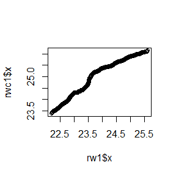

```r
rwM<-function(x0,sigma,N){ # R function
  x<-numeric(N)
  x[1]<-x0
  u<-runif(N)
  k<-0
  for(i in 2:N){
    y<-rnorm(1,mean=x[i-1],sd=sigma)
    if(u[i]<=exp(-abs(y))/exp(-abs(x[i-1]))) {
      x[i]<-y
      k<-k+1}
    else x[i]<-x[i-1]
  }
  return(list(x=x,k=k))
}

#Rcpp function
cppFunction('List rwMc(double x0, double sigma, int N){
NumericVector x(N);
x[0]=x0;
int k=0;
for(int i=1;i<N;i++){

double y=as<double>(rnorm(1,x[i-1], sigma));
double u=as<double>(runif(1));

if (u<=exp(-abs(y))/exp(-abs(x[i-1]))) {
x[i]=y;
k=k+1;
}
else x[i]=x[i-1];
}

return(List::create(Named("x")=x,Named("k")=k));
}')

sigma<-c(0.05,0.5,2,16)
x0<-25
N<-2000
set.seed(100)

rw1<-rwM(x0,sigma[1],N) #R samples
rw2<-rwM(x0,sigma[2],N)
rw3<-rwM(x0,sigma[3],N)
rw4<-rwM(x0,sigma[4],N)

rwc1<-rwMc(x0,sigma[1],N) #Rcpp samples
rwc2<-rwMc(x0,sigma[2],N)
rwc3<-rwMc(x0,sigma[3],N)
rwc4<-rwMc(x0,sigma[4],N)
#par(mfrow=c(2,2))

qqplot(rw1$x,rwc1$x) #compare qqplot
```

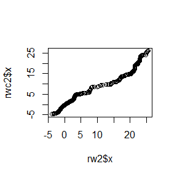

```r
qqplot(rw2$x,rwc2$x)
```

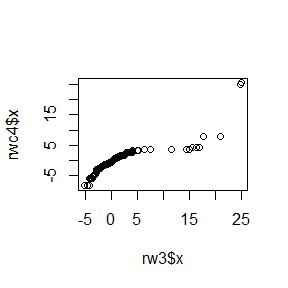

```r
qqplot(rw3$x,rwc4$x)
```

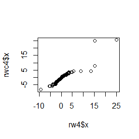

```r
qqplot(rw4$x,rwc4$x)
```

```r
#compare computing time
ts1<-microbenchmark(rwM(x0,sigma[1],N),rwMc(x0,sigma[1],N))
ts2<-microbenchmark(rwM(x0,sigma[2],N),rwMc(x0,sigma[2],N))
ts3<-microbenchmark(rwM(x0,sigma[3],N),rwMc(x0,sigma[3],N))
ts4<-microbenchmark(rwM(x0,sigma[4],N),rwMc(x0,sigma[4],N))
summary(ts1)[,c(1,3,5,6)]
```

```
##                    expr     lq  median     uq
## 1  rwM(x0, sigma[1], N) 3035.4 3117.70 3238.0
## 2 rwMc(x0, sigma[1], N)  310.5  314.55  318.8
```

```r
summary(ts2)[,c(1,3,5,6)]
```

```
##                    expr      lq  median     uq
## 1  rwM(x0, sigma[2], N) 3079.30 3153.15 3267.2
## 2 rwMc(x0, sigma[2], N)  268.35  272.30  278.3
```

```r
summary(ts3)[,c(1,3,5,6)]
```

```
##                    expr      lq  median      uq
## 1  rwM(x0, sigma[3], N) 3095.15 3178.70 3363.90
## 2 rwMc(x0, sigma[3], N)  285.00  287.35  290.85
```

```r
summary(ts4)[,c(1,3,5,6)]
```

```
##                    expr      lq  median      uq
## 1  rwM(x0, sigma[4], N) 3069.90 3123.55 3202.25
## 2 rwMc(x0, sigma[4], N)  284.45  286.95  290.10
```

As we show, we found that rcpp can save a lot of time.However the qqplot told us that the random numbers are not much the same for r and rcpp function.